# New York Mayoral Election 2017

Shuna

31 January, 2022

### Introduction

An election for Mayor of New York City was held on November 7, 2017.

> “Incumbent Democrat Bill de Blasio won reelection to a second term with 66.2% of the vote against Republican Nicole Malliotakis.” [^1]

This quote is extracted from the Wikipedia page.

### Data presented as a table

New York Mayoral Election 2017

| Borough | Candidate de Blasio | Candidate Malliotakis | Candidate Other |
| --- | --- | --- | --- |
| Bronx | 117,712 | 23,715 | 3,138 |
| Brooklyn | 254,755 | 74,343 | 10,602 |
| Manhattan | 190,312 | 53,853 | 10,186 |
| Queens | 171,867 | 94,911 | 8,974 |
| Staten Island | 25,466 | 70,125 | 2,747 |
| Total | 760,112 | 316,947 | 35,647 |

Source: CNN

### Data presented as a bar plot

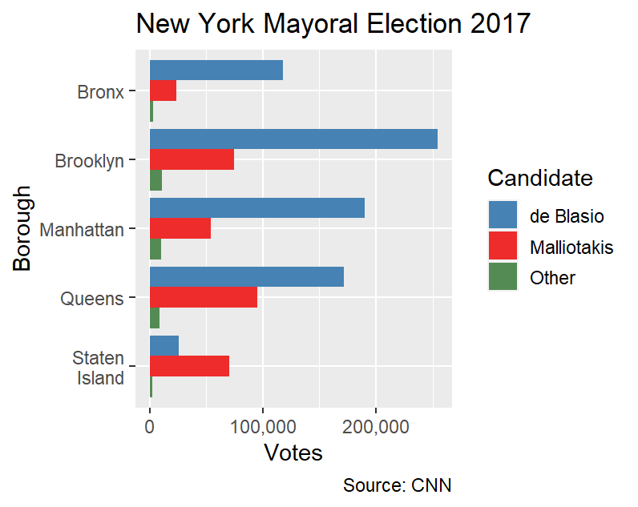

### What is better: table or bar plot?

With a table, we can easily obtain the exact numerical values and quantities without having to go an extra step of calculating it from the height of each bar. The total number of votes is much easier to represent in a table than a bar plot too. It also provides a more “objective” sense of comparison between the different values, as compared to bar plots. The latter may be more susceptible to “visual manipulation” to mislead viewers into making comparisons of inaccurate magnitudes (e.g. when the y axis does not start at 0).

However, if we wish to infer a trend or make other comparisons, a table does not provide as much visual convenience to aid us like a bar plot would. For example, we would not be able to visualize the exact magnitude to which de Blasio outcompeted his opponents, but a bar graph allows us to easily see that he received a landslide victory in most boroughs. If we wanted to understand the rough proportion of votes taken by other candidates at first glance, the proportions of each bar helps us reach a rough conclusion faster.

[^1]: Quote from https://en.wikipedia.org/wiki/2017_New_York_City_mayoral_election, accessed on 28 January 2022